# Abortion Opinion, 1980-2024

The most divisive issue in American politics, and whether opinion has actually moved

Democracy’s Data

Last updated September 13, 2026 at 10:53a EDT

*Abortion is the most divisive issue in American politics.* You have heard the sentence, and it smuggles in an assumption: a country this torn must be a country whose views are moving. Forty-four years of the same survey question can check that. This brief asks the question the sentence skips: has abortion opinion actually moved — and if so, whose?

The short answer, visible in the figures below, is that the country’s answers moved far less than its politics did. What moved was who gives which answer. That is a different kind of change, and the headline number cannot show it.

## The test

The measure is a four-option abortion question — an *item*, in survey language — numbered `VCF0838` in the ANES Time Series Cumulative Data File, 1948–2024. That file is collected by the University of Michigan and Stanford University for the American National Election Studies (ANES), the academic survey that has interviewed a national sample of Americans — a few thousand people chosen at random to stand in for the country — in every presidential election since 1948. It is free, but must be requested through a browser with an account at [electionstudies.org](https://electionstudies.org/data-center/anes-time-series-cumulative-data-file/). The item has been read from the same printed card, handed to the respondent by the interviewer, in 17 studies from 1980 to 2024. The ANES chapter introduces the cumulative file and its codebook; two companion briefs, party identification and ideology, built the identities this brief splits by.

Only a survey can hold this question, and no election ever grades the answer. A referendum counts votes on one state’s one proposal; it never measures what the country thinks about abortion in general, so there is no result to score these answers against. The method has to be the credential, and the credential here is constancy: the same four options, in the same words, for forty-four years. A claim about *change* is only as good as the thing that stayed the same.

The test runs in three parts. First, read the most recent study on its own, because a trend line is unreadable until you know what a single row means. Second, split that study by party and by ideology and measure both gradients — how steadily an answer climbs or falls from one end of each scale to the other. Third, follow all four options across every year, and follow both gradients with them.

## The data

Here is the question as the respondent meets it, verbatim, with five real rows of the file underneath.

```
The respondent is handed a booklet and asked which opinion best
agrees with their view. The four options, verbatim:

  1  By law, abortion should never be permitted.

  2  The law should permit abortion only in case of rape, incest,
     or when the woman's life is in danger.

  3  The law should permit abortion for reasons other than rape,
     incest, or danger to the woman's life, but only after the need
     for the abortion has been clearly established.

  4  By law, a woman should always be able to obtain an abortion as
     a matter of personal choice.

  9  DK; other

Five random rows from the 2024 study, with the two identity
columns this chapter uses alongside:

year  VCF0838  VCF0301  VCF0803  abortion_view
2024  3  3  5  Other reasons, but only after the
2024  3  3  4  Other reasons, but only after the
2024  4  1  2  Always, as a matter of personal ch
2024  4  1  1  Always, as a matter of personal ch
2024  4  2  4  Always, as a matter of personal ch

Option 3 is the one to watch. It is not a middle position between
1 and 4 -- it is a permission with a gatekeeper, and it is where
the movement of the last four years went.
```

Option 3 deserves a second read, because it is not a midpoint between never and always. It is a *permission with a gatekeeper* — abortion allowed, but only once someone has established that the need is real. A person choosing it has not split the difference; they have chosen a procedural answer to a question the other three options answer in principle. Keep it in view. It is where the last four years went.

Three decisions about how to sort the answers were made when these tables were built, and each is argued for elsewhere rather than repeated here. Party identification is kept at all seven points, because the party identification brief shows that collapsing the scale is exactly where the leaners disappear. Ideological self-placement — where people put themselves on a scale from extremely liberal to extremely conservative — keeps the people who said *haven’t thought much about it* as their own group, because the ideology brief shows the codebook files that answer under **Valid**. And code 9 on the abortion item itself, *don’t know*, is dropped, along with respondents not asked.

Five tables come out. `now.csv` is the most recent study’s four shares. `by_party.csv` and `by_ideology.csv` split that study by the two identities, one row per group, with each group’s full distribution. `overtime.csv` runs the four options across every study year, with a `pct_missing` column — 2008 is 55.3% missing on this item because, as the codebook records, a randomly chosen half of that year’s respondents was asked a different set of abortion questions instead. `gaps.csv` subtracts: Democrats minus Republicans, and liberals minus conservatives, in the share saying *always*, for every year.

> **Before you read on, commit to a view.** By the end of this brief you will have seen a party gradient and an ideology gradient on this question, both strong. **Which of the two do you expect was already strong in 1980, and which one had to be built?** Write down your answer.

## What it says about democracy

Start with what Americans said in 2024.

| The option as read | Respondents | Share |
| --- | --- | --- |
| Never permitted | 293 | 5.8% |
| Only for rape, incest, or danger to the woman’s life | 1,166 | 23.2% |
| Other reasons, but only after the need is established | 1,059 | 21.1% |
| Always, as a matter of personal choice | 2,503 | 49.9% |

Half of the people asked, 49.9%, take the fourth option: abortion as a matter of personal choice. 5.8% take the first, never permitted. The two absolute answers hold half the country between them, and the two conditional ones hold the rest.

Now the same study, split by the seven-point party scale.

| Party identification | Respondents | Never | Rape incest life | Need established | Always |
| --- | --- | --- | --- | --- | --- |
| Strong Democrat | 1,207 | 1.4% | 6.7% | 12.8% | 79.0% |
| Weak Democrat | 582 | 1.9% | 8.8% | 18.7% | 70.6% |
| Independent-Democrat | 670 | 1.5% | 8.1% | 20.1% | 70.3% |
| Independent-Independent | 330 | 5.5% | 19.1% | 23.3% | 52.1% |
| Independent-Republican | 624 | 8.5% | 38.5% | 27.2% | 25.8% |
| Weak Republican | 524 | 7.6% | 34.5% | 27.7% | 30.2% |
| Strong Republican | 1,059 | 13.2% | 46.3% | 24.8% | 15.7% |

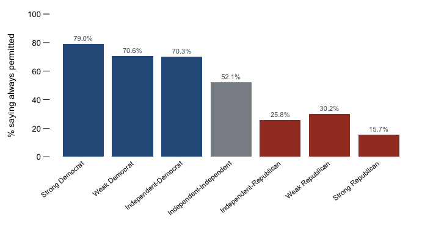

**Figure 1. The seven-point party scale against the abortion item, 2024.** Bars across the party scale, because the claim is about a gradient — how steadily an answer climbs or falls from strong Democrat to strong Republican. The buttons switch which of the four options is drawn, and hovering a bar gives that group’s whole distribution. Option 4, the one that gets reported, runs from 15.7% to 79.0%, a spread of 63.3 points; option 3, the gatekeeper answer, runs only from 12.8% to 27.7%. Roughly a quarter as steep, which is how it can absorb movement without registering as a partisan story.

The gradient runs the way you would expect, with one thing worth stopping on. **Leaning Republicans are further from the pro-choice position than weak Republicans**, at 25.8% against 30.2%. The people who decline the party label hold the more conservative view on this issue than the people who accept it. That is the same pattern the party identification brief found in vote choice, showing up in a second place. Fold the leaners into “independent,” as the file’s own three-category column invites, and you would report an independent group near 52.1% while the actual unaffiliated middle is far smaller.

Ideology sorts the same study even more sharply.

| Ideological self placement | Respondents | Never | Need established | Always |
| --- | --- | --- | --- | --- |
| Extremely liberal | 235 | 3.8% | 4.7% | 88.1% |
| Liberal | 758 | 0.8% | 9.2% | 86.3% |
| Slightly liberal | 515 | 1.4% | 20.2% | 72.4% |
| Moderate, middle of the road | 1,085 | 2.6% | 25.8% | 54.0% |
| Slightly conservative | 532 | 4.9% | 31.4% | 34.2% |
| Conservative | 928 | 9.9% | 26.2% | 15.1% |
| Extremely conservative | 278 | 27.7% | 13.3% | 12.6% |
| Haven’t thought much about it | 679 | 7.1% | 21.5% | 47.1% |

Now the whole series.

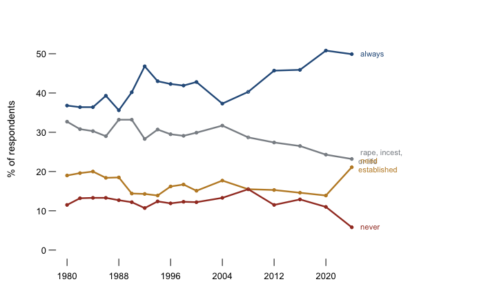

**Figure 2. All four options, every study year the item was asked.** Scrub across the plot to read all four shares at any year; the buttons mute a series so the others can be compared without it. Hollow points mark 2008, where the split half-sample leaves the item 55.3% missing. The line is drawn through that year rather than bridged silently, because a gap that has been filled in looks exactly like data.

| Option | Then | Now | Change |
| --- | --- | --- | --- |
| Never permitted | 11.0% | 5.8% | -5.2 |
| Only rape, incest, or life | 24.3% | 23.2% | -1.1 |
| Only after the need is established | 13.9% | 21.1% | +7.2 |
| Always, personal choice | 50.8% | 49.9% | -0.9 |

**The absolutist position roughly halved**, and the mass did not go to the opposite pole — *always permitted* fell slightly. It went into option 3, the permission with a gatekeeper, which gained 7.2 points. A reader watching only the headline number would conclude that nothing much happened between 2020 and 2024. Something quite large happened, and it happened in the categories nobody reports.

The last figure is the one the prediction prompt was about.

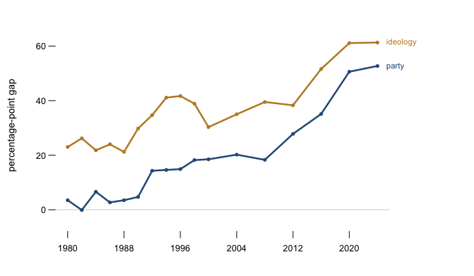

**Figure 3. The party gap and the ideology gap in the share saying always permitted.** Democrats minus Republicans, leaners included on both sides; liberals minus conservatives. Higher means further apart. Hovering reports the four shares behind the two differences, which is where the interesting part is.

The gap is a subtraction. In 1980, 37.3% of Democrats and 33.8% of Republicans took the *always* option, and 37.3 − 33.8 = 3.5: the party gap on abortion was **3.5 points**. Democrats and Republicans held almost the same distribution of views; abortion cut across the parties rather than between them. By 2024 the gap is **52.7 points**, and it widened mostly because one side moved: the Democratic share saying *always* rose 37.4 points between 1980 and 2024 while the Republican share fell 11.8. The ideology gap started at 23.0 points — already wide in 1980. Liberal and conservative meant something about abortion before the party labels did, and that gap widened too, to 61.3.

This is the finding the three-part test was built to deliver. The aggregate looks like a country whose mind changed slowly. Split it, and you see a country whose mind changed much less than its *sorting* did: roughly the same distribution of opinions, redistributed onto different teams. That is what “most divisive issue” turns out to mean in this file — not a country changing its answer, but a country reorganizing its parties around an answer it already had.[^1]

## What this brief cannot tell you

**2008 is 55.3% missing on this item**, and that is documented rather than broken: a random half sample received a branching series of questions instead of the four-option card. Read the codebook note and your sample is halved for a known reason; miss it and 2008 looks like a collapse in response.

**Four options are not a scale.** The distance from *never* to *rape, incest or life* is not the same quantity as the distance from *need established* to *always*, so this brief reports shares and differences of shares, and never a mean. A mean of these four numbers would be arithmetic on labels.

**Nothing here is weighted** — no answer is counted more than another to make the sample’s mix match the country’s — so every percentage describes the people ANES interviewed rather than the country. The file’s weight column, `VCF0009z`, is there for a reader who wants to apply it.

**The 2020-to-2024 movement invites a *Dobbs* story, and this brief does not tell one.** *Dobbs v. Jackson Women’s Health Organization* is the June 2022 decision in which the Supreme Court overturned *Roe v. Wade* and returned abortion law to the states, and it falls squarely between the two studies.[^2] Two studies four years apart cannot separate a court decision’s effect from everything else that happened, and the codebook records no wording change that would explain it either. What can be said is what the table says: the movement was out of the absolute prohibition and into the conditional permission, and not toward personal choice.

**And the two gradients are not independent of each other.** Liberals are mostly Democrats and conservatives mostly Republicans, and this brief never holds one identity constant while varying the other. Which of the two is doing the work is a real question and a different brief.

## Extensions

None of these is answered above, and every one can be answered from the tables the Sources section hands over.

- `gaps.csv` carries `ind_always` and `notplaced_always`, two middle groups no figure above draws. Follow both across the years. Do they move with the country, or with one party?
- `by_party.csv` has the full distribution for every group, including `pct_2`, the rape-incest-life option. Which groups choose it most, and does it run with the gradient or against it?
- `overtime.csv` has all four options by year. Find the year each option peaks. Does any of the four ever hold a majority?
- `overtime.csv` has `pct_missing`. Set 2008 aside and find the next-highest years. Is item-missingness drifting up as the politics heat up, or holding steady?

Two stretch ideas point past the spreadsheet. The General Social Survey asks its own battery of abortion questions, in a file anyone can download from NORC at the University of Chicago at https://gss.norc.org/us/en/gss/get-the-data.html — rebuild Figure 2’s flat top line from `abany` and check whether it replicates. And after 2022, several states put abortion directly on the ballot; find two of those referendum results and ask which of the four ANES options the winning side’s share sits closest to.

## Sources

**Data**

- American National Election Studies. *ANES Time Series Cumulative Data File (1948–2024)*, version of 5 February 2026. Ann Arbor, MI and Palo Alto, CA: University of Michigan and Stanford University. https://electionstudies.org/data-center/anes-time-series-cumulative-data-file/ The file must be requested through a browser with a free account; the ANES chapter describes what it costs to get.
- ANES. *Time Series Cumulative Data File Codebook*, same release. The four options and the 2008 split-sample note are quoted from it directly.

**Academic literature**

- Adams, Greg D. (1997). “Abortion: Evidence of an Issue Evolution.” *American Journal of Political Science* 41(3): 718–737. https://www.jstor.org/stable/2111673
- Carmines, Edward G. and James A. Stimson (1989). *Issue Evolution: Race and the Transformation of American Politics.* Princeton University Press. https://press.princeton.edu/books/paperback/9780691023311/issue-evolution
- Layman, Geoffrey C. (2001). *The Great Divide: Religious and Cultural Conflict in American Party Politics.* Columbia University Press. https://cup.columbia.edu/book/the-great-divide/9780231120593

**Court decisions**

- *Roe v. Wade*, 410 U.S. 113 (1973). https://www.law.cornell.edu/supremecourt/text/410/113
- *Dobbs v. Jackson Women’s Health Organization*, 597 U.S. 215 (2022). https://www.law.cornell.edu/supremecourt/text/19-1392

**The data itself**

Every figure above is drawn from these tables. They are plain CSV, they open in a spreadsheet, and they are yours to take further.

`by_ideology.csv`, `by_party.csv`, `gaps.csv`, `now.csv`, `overtime.csv`

[^1]: Greg D. Adams traced the first two decades of this re-sorting in the same data and called it, after Carmines and Stimson, an *issue evolution*: Greg D. Adams, “Abortion: Evidence of an Issue Evolution,” *American Journal of Political Science* 41, no. 3 (1997): 718–737, https://www.jstor.org/stable/2111673; Edward G. Carmines and James A. Stimson, *Issue Evolution: Race and the Transformation of American Politics* (Princeton: Princeton University Press, 1989), https://press.princeton.edu/books/paperback/9780691023311/issue-evolution.
[^2]: *Dobbs v. Jackson Women’s Health Organization*, 597 U.S. 215 (2022), https://www.law.cornell.edu/supremecourt/text/19-1392; *Roe v. Wade*, 410 U.S. 113 (1973), https://www.law.cornell.edu/supremecourt/text/410/113.